# Neural Network From Scratch

In this notebook we build a 2-layer neural network for binary classification from scratch in numpy. We write the forward pass, the cross-entropy loss, and the backpropagation step ourselves.

First, the imports.

```python
import numpy as np
import matplotlib.pyplot as plt
from sklearn.datasets import make_moons
from sklearn.model_selection import train_test_split
from sklearn.neural_network import MLPClassifier

np.random.seed(42)
```

## The dataset

We use sklearn's `make_moons`, two interleaving half circles. The data is not linearly separable so we need the hidden layer.

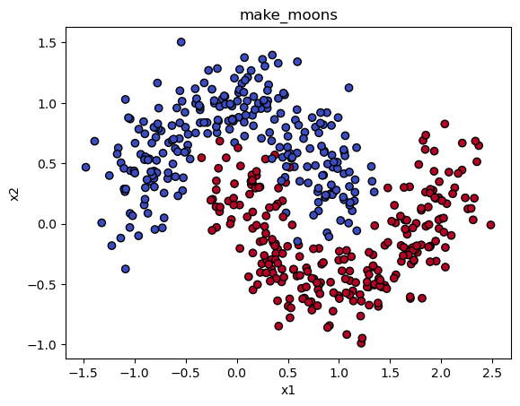

```
X shape: (500, 2), t shape: (500, 1)
```

```python
X, t = make_moons(n_samples=500, noise=0.2, random_state=42)
t = t.reshape(-1, 1)

X_train, X_test, t_train, t_test = train_test_split(X, t, test_size=0.2, random_state=42)

plt.scatter(X[:, 0], X[:, 1], c=t.ravel(), cmap='coolwarm', edgecolors='k')
plt.title('make_moons')
plt.xlabel('x1')
plt.ylabel('x2')
plt.show()

print(f'X shape: {X.shape}, t shape: {t.shape}')
```

## Network architecture

Two layers. One hidden, one output.

- Input: 2 features (x1, x2)
- Hidden: 4 units with sigmoid activation
- Output: 1 unit with sigmoid activation (binary classification)

Forward pass in matrix form:

$$ \mathbf{A}^{(1)} = \mathbf{X} \mathbf{W}^{(1)} + \mathbf{b}^{(1)} $$ $$ \mathbf{Z} = \sigma(\mathbf{A}^{(1)}) $$ $$ \mathbf{A}^{(2)} = \mathbf{Z} \mathbf{W}^{(2)} + \mathbf{b}^{(2)} $$ $$ \mathbf{Y} = \sigma(\mathbf{A}^{(2)}) $$

Cross-entropy error averaged over all $N$ samples:

$$ E = -\frac{1}{N} \sum_{n=1}^{N} \big[ t_n \ln(y_n) + (1 - t_n) \ln(1 - y_n) \big] $$

For backprop, sigmoid and cross-entropy cancel at the output layer and we get:

$$ \boldsymbol{\delta}^{(2)} = \mathbf{Y} - \mathbf{T} $$

Hidden delta backpropagates through the output weights and the sigmoid derivative $h'(a) = z(1-z)$:

$$ \boldsymbol{\delta}^{(1)} = (\boldsymbol{\delta}^{(2)} \mathbf{W}^{(2)\top}) \odot \mathbf{Z} \odot (1 - \mathbf{Z}) $$

Weight gradients are dot products of the activations with the next delta:

$$ \nabla_{\mathbf{W}^{(2)}} E = \frac{1}{N} \mathbf{Z}^\top \boldsymbol{\delta}^{(2)}, \quad \nabla_{\mathbf{W}^{(1)}} E = \frac{1}{N} \mathbf{X}^\top \boldsymbol{\delta}^{(1)} $$

## Parameter initialization

Weights are small random numbers scaled by 0.01, biases are zero. Zero weights cause all hidden units to learn the same thing (symmetry problem), so we use randomness to break it.

```python
def initialize_parameters(D, M):
    W1 = np.random.randn(D, M) * 0.01
    b1 = np.zeros((1, M))
    W2 = np.random.randn(M, 1) * 0.01
    b2 = np.zeros((1, 1))
    return W1, b1, W2, b2
```

## Sigmoid

```python
def sigmoid(a):
    return 1 / (1 + np.exp(-a))
```

## Forward pass

Returns all four intermediate matrices. Z and Y are needed for backprop later.

```python
def forward_propagation(X, W1, b1, W2, b2):
    A1 = X @ W1 + b1
    Z = sigmoid(A1)
    A2 = Z @ W2 + b2
    Y = sigmoid(A2)
    return A1, Z, A2, Y
```

## Cross-entropy error

Add a tiny epsilon inside the log to avoid `log(0)` when a prediction gets very close to 0 or 1.

```python
def compute_error(Y, T):
    eps = 1e-8
    return -np.mean(T * np.log(Y + eps) + (1 - T) * np.log(1 - Y + eps))
```

## Backward pass

Output delta is `Y - T`. Backpropagate to hidden layer, divide by N for averaged gradients. `keepdims=True` on the bias sums keeps shapes `(1, M)` and `(1, 1)` for broadcasting later.

```python
def backward_propagation(X, T, W2, Z, Y):
    N = X.shape[0]

    delta2 = Y - T
    grad_W2 = (Z.T @ delta2) / N
    grad_b2 = np.sum(delta2, axis=0, keepdims=True) / N

    delta1 = (delta2 @ W2.T) * Z * (1 - Z)
    grad_W1 = (X.T @ delta1) / N
    grad_b1 = np.sum(delta1, axis=0, keepdims=True) / N

    return grad_W1, grad_b1, grad_W2, grad_b2
```

## Parameter update

Standard gradient descent.

```python
def update_parameters(W1, b1, W2, b2, grad_W1, grad_b1, grad_W2, grad_b2, eta):
    W1 -= eta * grad_W1
    b1 -= eta * grad_b1
    W2 -= eta * grad_W2
    b2 -= eta * grad_b2
    return W1, b1, W2, b2
```

## Training loop

Prints the error every 500 iterations.

```python
def train(X, T, M=4, eta=0.5, num_iterations=5000):
    D = X.shape[1]
    W1, b1, W2, b2 = initialize_parameters(D, M)
    losses = []

    for i in range(num_iterations):
        A1, Z, A2, Y = forward_propagation(X, W1, b1, W2, b2)
        E = compute_error(Y, T)
        losses.append(E)

        grad_W1, grad_b1, grad_W2, grad_b2 = backward_propagation(X, T, W2, Z, Y)
        W1, b1, W2, b2 = update_parameters(W1, b1, W2, b2, grad_W1, grad_b1, grad_W2, grad_b2, eta)

        if i % 500 == 0:
            print(f'iter {i:>5}: error = {E:.4f}')

    return W1, b1, W2, b2, losses
```

```python
W1, b1, W2, b2, losses = train(X_train, t_train, M=4, eta=0.5, num_iterations=5000)
```

```
iter     0: error = 0.6931
iter   500: error = 0.2895
iter  1000: error = 0.2860
iter  1500: error = 0.2845
iter  2000: error = 0.2835
iter  2500: error = 0.2826
iter  3000: error = 0.2818
iter  3500: error = 0.2809
iter  4000: error = 0.2798
iter  4500: error = 0.2783
```

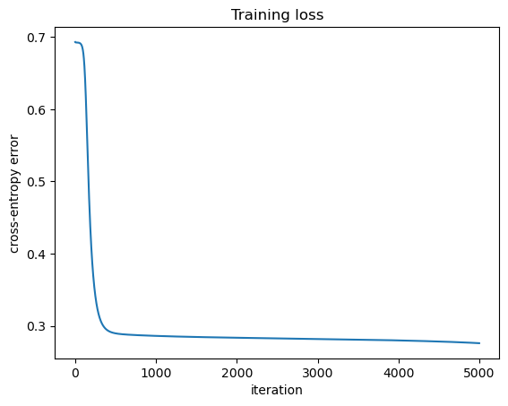

```python
plt.plot(losses)
plt.xlabel('iteration')
plt.ylabel('cross-entropy error')
plt.title('Training loss')
plt.show()
```

Error drops fast, then plateaus around 0.28. Full-batch GD so the curve is smooth.

## Decision boundary

Build a grid over the feature space, run the forward pass on every grid point, and contour the predicted probability.

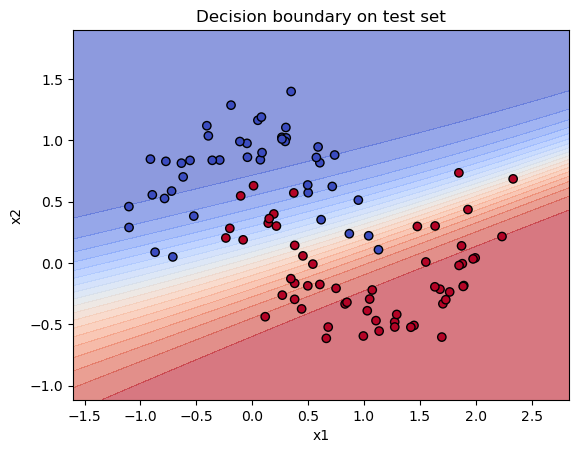

```python
def plot_decision_boundary(X, T, W1, b1, W2, b2, title='Decision boundary'):
    x1_min, x1_max = X[:, 0].min() - 0.5, X[:, 0].max() + 0.5
    x2_min, x2_max = X[:, 1].min() - 0.5, X[:, 1].max() + 0.5
    xx, yy = np.meshgrid(np.linspace(x1_min, x1_max, 200),
                         np.linspace(x2_min, x2_max, 200))
    grid = np.c_[xx.ravel(), yy.ravel()]

    _, _, _, Y_grid = forward_propagation(grid, W1, b1, W2, b2)
    Y_grid = Y_grid.reshape(xx.shape)

    plt.contourf(xx, yy, Y_grid, levels=20, cmap='coolwarm', alpha=0.6)
    plt.scatter(X[:, 0], X[:, 1], c=T.ravel(), cmap='coolwarm', edgecolors='k')
    plt.title(title)
    plt.xlabel('x1')
    plt.ylabel('x2')
    plt.show()

plot_decision_boundary(X_test, t_test, W1, b1, W2, b2, title='Decision boundary on test set')
```

## Does it match sklearn?

Training `MLPClassifier` with the same architecture (4 sigmoid hidden units, SGD) to compare. Should be close if our backprop is correct.

```python
_, _, _, Y_pred = forward_propagation(X_test, W1, b1, W2, b2)
our_accuracy = np.mean((Y_pred > 0.5) == t_test)
print(f'From-scratch accuracy: {our_accuracy:.3f}')

sk_mlp = MLPClassifier(hidden_layer_sizes=(4,), activation='logistic',
                       solver='sgd', learning_rate_init=0.5,
                       max_iter=5000, random_state=42)
sk_mlp.fit(X_train, t_train.ravel())
sk_accuracy = sk_mlp.score(X_test, t_test.ravel())
print(f'sklearn accuracy:      {sk_accuracy:.3f}')
```

```
From-scratch accuracy: 0.860
sklearn accuracy:      0.850
```

Both around 85%. Backprop is working.